# FinalProjectGraphs

Williem Encarnacion, Jerome Veix, Paula Palles, Zacharia Mwaura

4/27/2022

```r
#install.packages("rapport")
library(RColorBrewer)
library(GISTools)
```

```r
library(corrplot)
library(rapport)
library(mlogit)
#install.packages("maps")
#install.packages("maptools")
#install.packages("sp")
library(maps)
library(maptools)
library(sp)
suppressMessages(library(car))
colours <- brewer.pal(8, "Pastel2")
coloursT <- add.alpha(colours, .5)
```

## File

```r
police <- read.csv("C:/Users/jamir/Downloads/fatal-police-shootings-data.csv")
policeData <- na.omit(police)
policeData1 <-policeData
str(police)
```

```
## 'data.frame':    6953 obs. of  17 variables:
##  $ id                     : int  3 4 5 8 9 11 13 15 16 17 ...
##  $ name                   : chr  "Tim Elliot" "Lewis Lee Lembke" "John Paul Quintero" "Matthew Hoffman" ...
##  $ date                   : chr  "2015-01-02" "2015-01-02" "2015-01-03" "2015-01-04" ...
##  $ manner_of_death        : chr  "shot" "shot" "shot and Tasered" "shot" ...
##  $ armed                  : chr  "gun" "gun" "unarmed" "toy weapon" ...
##  $ age                    : int  53 47 23 32 39 18 22 35 34 47 ...
##  $ gender                 : chr  "M" "M" "M" "M" ...
##  $ race                   : chr  "A" "W" "H" "W" ...
##  $ city                   : chr  "Shelton" "Aloha" "Wichita" "San Francisco" ...
##  $ state                  : chr  "WA" "OR" "KS" "CA" ...
##  $ signs_of_mental_illness: chr  "True" "False" "False" "True" ...
##  $ threat_level           : chr  "attack" "attack" "other" "attack" ...
##  $ flee                   : chr  "Not fleeing" "Not fleeing" "Not fleeing" "Not fleeing" ...
##  $ body_camera            : chr  "False" "False" "False" "False" ...
##  $ longitude              : num  -123.1 -122.9 -97.3 -122.4 -104.7 ...
##  $ latitude               : num  47.2 45.5 37.7 37.8 40.4 ...
##  $ is_geocoding_exact     : chr  "True" "True" "True" "True" ...
```

```r
str(policeData)
```

```
## 'data.frame':    6121 obs. of  17 variables:
##  $ id                     : int  3 4 5 8 9 11 13 15 16 17 ...
##  $ name                   : chr  "Tim Elliot" "Lewis Lee Lembke" "John Paul Quintero" "Matthew Hoffman" ...
##  $ date                   : chr  "2015-01-02" "2015-01-02" "2015-01-03" "2015-01-04" ...
##  $ manner_of_death        : chr  "shot" "shot" "shot and Tasered" "shot" ...
##  $ armed                  : chr  "gun" "gun" "unarmed" "toy weapon" ...
##  $ age                    : int  53 47 23 32 39 18 22 35 34 47 ...
##  $ gender                 : chr  "M" "M" "M" "M" ...
##  $ race                   : chr  "A" "W" "H" "W" ...
##  $ city                   : chr  "Shelton" "Aloha" "Wichita" "San Francisco" ...
##  $ state                  : chr  "WA" "OR" "KS" "CA" ...
##  $ signs_of_mental_illness: chr  "True" "False" "False" "True" ...
##  $ threat_level           : chr  "attack" "attack" "other" "attack" ...
##  $ flee                   : chr  "Not fleeing" "Not fleeing" "Not fleeing" "Not fleeing" ...
##  $ body_camera            : chr  "False" "False" "False" "False" ...
##  $ longitude              : num  -123.1 -122.9 -97.3 -122.4 -104.7 ...
##  $ latitude               : num  47.2 45.5 37.7 37.8 40.4 ...
##  $ is_geocoding_exact     : chr  "True" "True" "True" "True" ...
##  - attr(*, "na.action")= 'omit' Named int [1:832] 128 770 810 820 933 941 966 991 1338 1353 ...
##   ..- attr(*, "names")= chr [1:832] "128" "770" "810" "820" ...
```

## Graph of race and proportions

```r
# policeData$threat_level <- factor(policeData$threat_level,
#                        levels = c("attack", "other","undetermined") ,
#                        labels = c(0,1,2))

prop <- NULL
races <- unique(policeData$race)
for (i in 1:length(races)){
  prop[i] <- sum(policeData$race == races[i])/length(policeData$race)

}
races
```

```
## [1] "A" "W" "H" "B" "O" ""  "N"
```

```r
prop
```

```
## [1] 0.015683712 0.453520667 0.166312694 0.238359745 0.007515112 0.104884823
## [7] 0.013723248
```

```r
#policeData$race <- factor(as.numeric(as.character(policeData$race,
                      #levels = c("A", "W", "H", "B", "O" ,"" , "N") ,
                      #labels = c(0,1,2,3,4,5,6))))

#as.numeric(as.character(policeData$race))

#"A" "W" "H" "B" "O" ""  "N"
#str(policeData)
#policeData


prop1 <- NULL
prop1 <- c(0.059 , 0.763, 0.185 ,0.134,  0 ,  0   , 0.013)
str(prop1)
```

```
##  num [1:7] 0.059 0.763 0.185 0.134 0 0 0.013
```

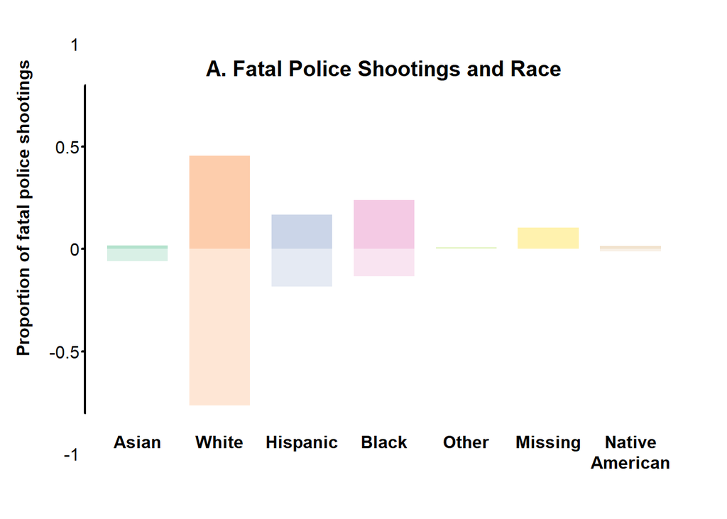

```r
xPos1 <- barplot(prop, ylim=c(-0.8,0.8),axes=FALSE, col=colours,border=NA,beside=TRUE,space=c(0.35))
axis(2, at=pretty(c(-0.8,0.8)), tck=-.01,lwd=2,labels = FALSE )
mtext(pretty(c(-0.8,0.8)),2,at=pretty(c(-0.8,0.8)), las=1, line=.25)
mtext(c("Asian", "White", "Hispanic", "Black", "Other" ,"Missing" , "Native\nAmerican"),1, at=xPos1, line=.25, font=2,cex=1,padj =1)
mtext("Proportion of fatal police shootings",2,line =2.5, font =2, at=0.2,cex=1)
mtext("A. Fatal Police Shootings and Race",3,line =.25, font =2,cex=1.25)

xPos2 <- barplot((-1*(prop1)), ylim=c(-0.8,0.8),axes=FALSE, col=coloursT,border=NA,beside=TRUE,space=c(0.35),add=TRUE)
```

```r
#barplot(prop)
```

If you compare these ratios to the percentage based off census data:

Data Set:

“A” “W” “H” “B” “O” “” “N” 0.015683712 0.453520667 0.166312694 0.238359745 0.007515112 0.104884823 0.013723248

Census Data:

“A” “W” “H” “B” “O” “” “N” 0.059 0.763 0.185 0.134 NA NA 0.013

Black people are over represented in this data set as more percentage of them are shot and make up a higher popultion in the dataset than in real life. The dataset doesn’t take into account that there are higher populations of white folks so that’s why there is more discrepancies than what meets news coverage.